# Part 1 - Gene expression mean analysis

mcgrathjes

2025-10-06

## Part 1 - Importing files, data wrangling, mathematical operations, plots and saving code on GitHub

The file “gene_expression.tsv” contains RNA-seq count data for three samples of interest. The following report will read in files from a public github repository https://github.com/ghazkha/Assessment4.git, configure rows and columns and analyse the data for several parameters.

### 1. Read in the file and make gene identifiers the row names

Using raw data from https://github.com/ghazkha/Assessment4.git, we will download the file “gene_expression.tsv” and set the row names as the gene identifiers which are listed in the first column `row.names=1` under the heading “Name_Description”, eg. ENSG00000223972.5_DDX11L1.

The following table shows values for the first six genes.

```
##                               GTEX.1117F.0226.SM.5GZZ7 GTEX.1117F.0426.SM.5EGHI
## ENSG00000223972.5_DDX11L1                            0                        0
## ENSG00000227232.5_WASH7P                           187                      109
## ENSG00000278267.1_MIR6859-1                          0                        0
## ENSG00000243485.5_MIR1302-2HG                        1                        0
## ENSG00000237613.2_FAM138A                            0                        0
## ENSG00000268020.3_OR4G4P                             0                        1
##                               GTEX.1117F.0526.SM.5EGHJ
## ENSG00000223972.5_DDX11L1                            0
## ENSG00000227232.5_WASH7P                           143
## ENSG00000278267.1_MIR6859-1                          1
## ENSG00000243485.5_MIR1302-2HG                        0
## ENSG00000237613.2_FAM138A                            0
## ENSG00000268020.3_OR4G4P                             0
```

### 2. Make a new column which is the mean of the other columns

Column 4 “Mean_Count” is added to the table with rounding to 3 significant figures and saved as a new variable.

The following table shows values for the first six genes.

```
##                               GTEX.1117F.0226.SM.5GZZ7 GTEX.1117F.0426.SM.5EGHI
## ENSG00000223972.5_DDX11L1                            0                        0
## ENSG00000227232.5_WASH7P                           187                      109
## ENSG00000278267.1_MIR6859-1                          0                        0
## ENSG00000243485.5_MIR1302-2HG                        1                        0
## ENSG00000237613.2_FAM138A                            0                        0
## ENSG00000268020.3_OR4G4P                             0                        1
##                               GTEX.1117F.0526.SM.5EGHJ Mean_Count
## ENSG00000223972.5_DDX11L1                            0      0.000
## ENSG00000227232.5_WASH7P                           143    146.000
## ENSG00000278267.1_MIR6859-1                          1      0.333
## ENSG00000243485.5_MIR1302-2HG                        0      0.333
## ENSG00000237613.2_FAM138A                            0      0.000
## ENSG00000268020.3_OR4G4P                             0      0.333
```

### 3. List the 10 genes with the highest mean expression

Using the new Mean_Count variable, we create a new data frame subset called “mean_table” comprised of gene identifiers and their mean count values. We then order the data from largest to smallest mean value and display the top 10 genes with highest mean expression.

```
##                            Gene Mean_Count
## 56179  ENSG00000198804.2_MT-CO1     529000
## 56191  ENSG00000198886.2_MT-ND4     514000
## 56186  ENSG00000198938.2_MT-CO3     505000
## 56169  ENSG00000198888.2_MT-ND1     404000
## 56185 ENSG00000198899.2_MT-ATP6     330000
## 56198  ENSG00000198727.2_MT-CYB     302000
## 56173  ENSG00000198763.3_MT-ND2     284000
## 16618   ENSG00000211445.11_GPX3     270000
## 56182  ENSG00000198712.1_MT-CO2     266000
## 18688 ENSG00000156508.17_EEF1A1     232000
```

### 4. Determine the number of genes with a mean <10

We will create a subset called “low_mean” that contains all data with a Mean_count of less than 10. By counting the rows in this subset, we can see that there are 35,988 genes with a mean <10.

```
## [1] 35988
```

### 5. Make a histogram plot of the mean values

Considering the large number of genes with a mean <10, we evaluate the summary statistics of numeric vector “Mean_Count” to assess appropriate histogram parameters.

```
##  num [1:56200] 0 146 0.333 0.333 0 0.333 0.667 1 1.67 1 ...
```

```
##      Min.   1st Qu.    Median      Mean   3rd Qu.      Max.
##      0.00      0.00      1.33    827.17     89.00 529000.00
```

We can see that there is a large range of values from 0.00 to 529,000 in this data set. There is a significant right skew demonstrated by the lower half of the genes (Min-Median) having a range of 0.00-1.33 and the upper half of the genes (Median-Max) extending from 1.33 to 529,000.

Due to these characteristics, it is appropriate to log10 transform the data to visually display a histogram of this data as described by Love *et al.* (2022). As we have known values of 0 in our data set, we add “+1” to the log transformation.

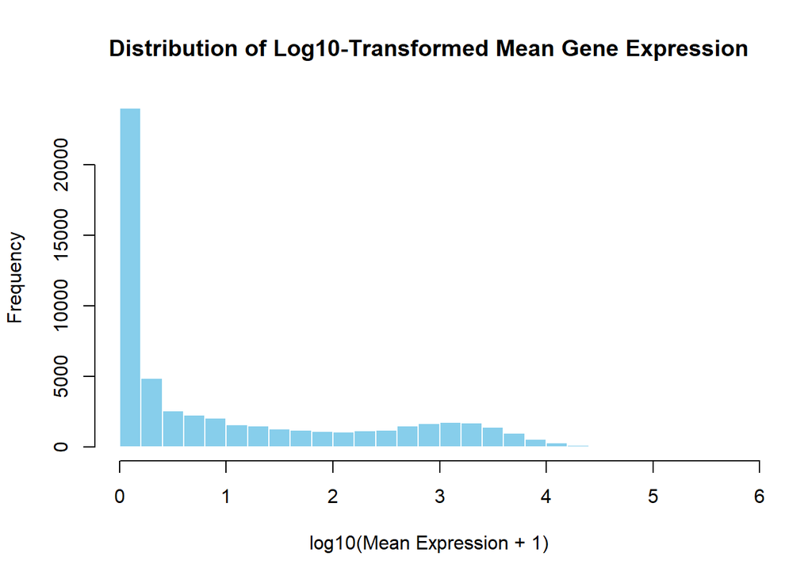

[output not shown]